# Part I - (Dataset Exploration Title)

### Qualitative variables

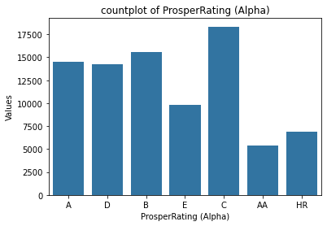

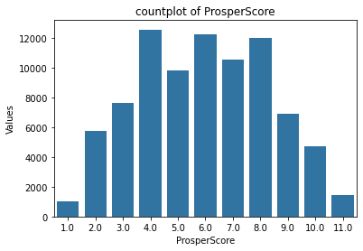

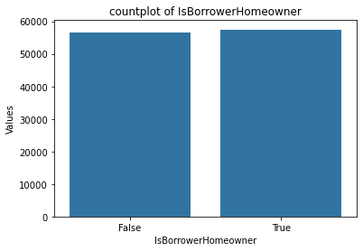

```python
def countplot(df:pd.DataFrame,cols,rotation=0)->pd.DataFrame:
    """
    -- plot countplot for qualitative plot
    """
    sb.countplot(data=df,x=cols,color=sb.color_palette()[0])
    plt.xlabel(cols)
    plt.ylabel('Values')
    plt.title(f'countplot of {cols}')
    plt.xticks(rotation=rotation)
    plt.show()


for i in ['ProsperRating (Alpha)','ProsperScore','IsBorrowerHomeowner']:
    countplot(df_used_cols,i)
```

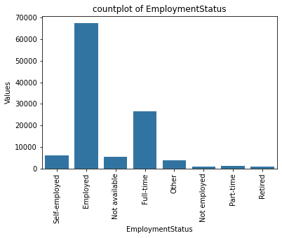

```python
countplot(df_used_cols,'EmploymentStatus',rotation=90)
```

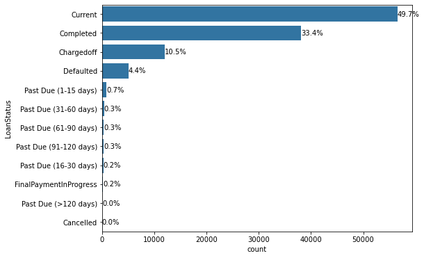

```python
plt.figure(figsize=(8,6))
sb.countplot(data=df_used_cols,y='LoanStatus',color=sb.color_palette()[0],order=df_used_cols.LoanStatus.value_counts().index);

for i in range(df_used_cols.LoanStatus.value_counts().shape[0]):
    count = df_used_cols.LoanStatus.value_counts()[i]
    n_loan_status = df_used_cols['LoanStatus'].value_counts().sum()
    p_string = '{:0.1f}%'.format(100*count/n_loan_status)
    plt.text(count, i, p_string, va='center')
```

# Observation on Univariate Exploration

continuing to qualitative,I used countplot to analysis the frequency of different categories in different features of the dataset. Starting with ProsperRating (Alpha), we can see that "C" category outweighs others, whereby 4 is customer risk sccore with high values in the properscore columns. Borrow home owner status are quite balanced and those who are employed are the one with the most loan compared to the other employee job status. In loan status, it can be seen that people on current loan outweighs others with 49.7% followed by those who completed their loans.

## Bivariate Exploration

> In this section, investigate relationships between pairs of variables in your data. Make sure the variables that you cover here have been introduced in some fashion in the previous section (univariate exploration).

## relationship between quantitative columms

```python
df_used_cols.info()
```

```
<class 'pandas.core.frame.DataFrame'>
RangeIndex: 113937 entries, 0 to 113936
Data columns (total 18 columns):
 #   Column                     Non-Null Count   Dtype
---  ------                     --------------   -----
 0   ListingCreationDate        113937 non-null  datetime64[ns]
 1   Term                       113937 non-null  int64
 2   LoanStatus                 113937 non-null  object
 3   BorrowerAPR                113912 non-null  float64
 4   BorrowerRate               113937 non-null  float64
 5   ProsperRating (Alpha)      84853 non-null   object
 6   ProsperScore               84853 non-null   category
 7   ListingCategory (numeric)  113937 non-null  int64
 8   BorrowerState              108422 non-null  object
 9   EmploymentStatus           111682 non-null  object
 10  IsBorrowerHomeowner        113937 non-null  bool
 11  DelinquenciesLast7Years    112947 non-null  float64
 12  StatedMonthlyIncome        113937 non-null  float64
 13  TotalProsperLoans          113937 non-null  int64
 14  LoanOriginalAmount         113937 non-null  int64
 15  LoanOriginationDate        113937 non-null  datetime64[ns]
 16  Recommendations            113937 non-null  int64
 17  Investors                  113937 non-null  int64
dtypes: bool(1), category(1), datetime64[ns](2), float64(4), int64(6), object(4)
memory usage: 14.1+ MB
```

```python
def scatter(df:pd.DataFrame,col1,col2)->pd.DataFrame:
    plt.figure(figsize=(10,8))
    sb.set()
    sb.regplot(data = df, x = col1, y = col2);
    plt.xlabel(col1)
    plt.ylabel(col2)
    plt.title(f'A scatterplot of {col1} against {col2}',fontsize=15 )
```

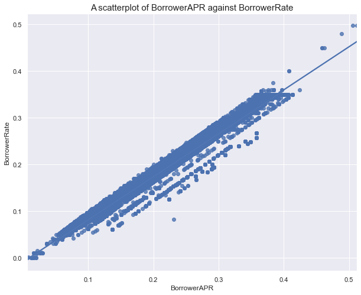

```python
scatter(df_used_cols,'BorrowerAPR','BorrowerRate')
```

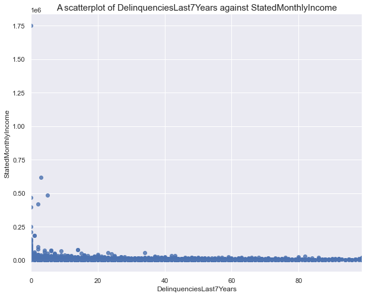

```python
scatter(df_used_cols,'DelinquenciesLast7Years','StatedMonthlyIncome')
```

```python
#log transform function
def log_trans(x, inverse = False):
    if not inverse:
        return np.log10(x)
    else:
        return np.power(10, x)
```

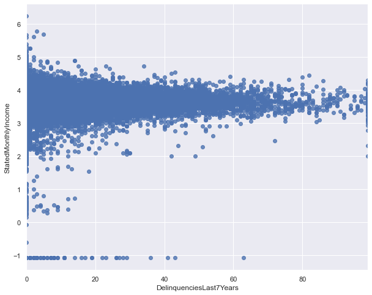

```python
#apply log transform on Deli
plt.figure(figsize=(10,8))
sb.regplot(df_used_cols['DelinquenciesLast7Years'],df_used_cols['StatedMonthlyIncome'].apply(log_trans));
```

### Observation on relationship between (quantitative vs quantitative columns)

Using scatterplot, three plots were plotted to depict the relationship betweeen different quamtitative variables. To begin with the first plot, it illustrates the relation between `borrowerAPR` and `BorrowerRate`. It can be seen that there is a strong positive relationship, means that if one variable increase, another variable will also increase. Same as the first plot, the second plot highlights the relationship between `DelinquenciesLast7Years` and `Statemonthlyincome`. The second doesn't provide a good picture to analyse those variable relationshi which might be due to high values of `Statemonthlyincome`. Therefore log transformation was applied to `Statemonthlyincome` to provide a good plot. It can be seen in the third plot that there is no relationship between the two variables.

## relationship between quantitative columms and qualitative columns

###### relationship between prosperscore and borrowerAPR

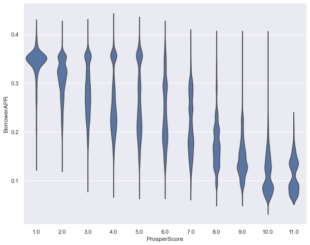

```python
plt.figure(figsize=(10,8))
sb.violinplot(data=df_used_cols, x='ProsperScore', y='BorrowerAPR',color=sb.color_palette()[0], inner=None);
```

###### relationship between employment status,ProsperRating (Alpha) and borrowerAPR mean

```python
def plot_(df:pd.DataFrame,col1,col2):
    df_mean = df.groupby(col1)[col2].mean()
    plt.figure(figsize=(10,8))
    plt.pie(df_mean, labels = df_mean.index, startangle = 90,
     autopct='%1.1f%%')
    plt.axis('square')
    plt.title(f"{col1} vs {col2}",fontsize=15,fontweight="bold");
```

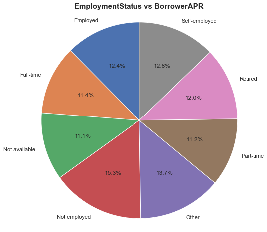

```python
plot_(df_used_cols,'EmploymentStatus','BorrowerAPR')
```

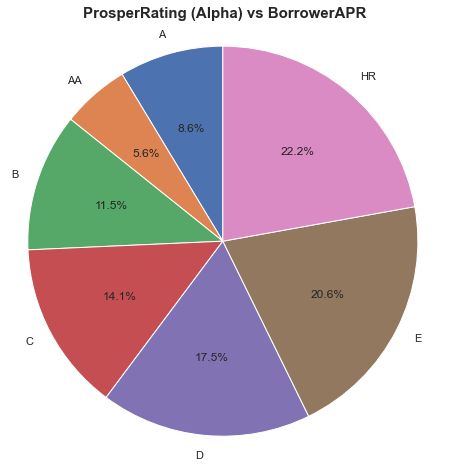

```python
plot_(df_used_cols,'ProsperRating (Alpha)','BorrowerAPR')
```

## relationship between qualitative columms

###### relationship between loan status and ProsperRating(Alpha)

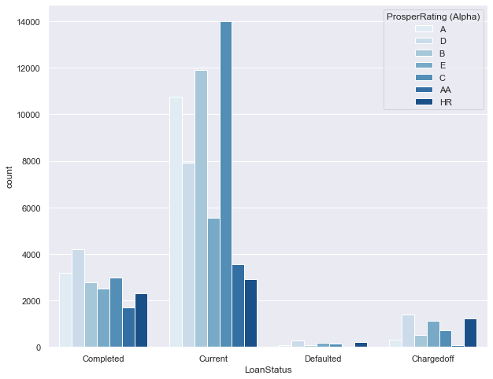

```python
#extract some loan status information
plt.figure(figsize=(10,8))
df_used_cols_loan_status = df_used_cols[df_used_cols['LoanStatus'].isin(['Current','Completed','Chargedoff','Defaulted'])]
sb.countplot(data = df_used_cols_loan_status, x = 'LoanStatus', hue = 'ProsperRating (Alpha)', palette = 'Blues');
```

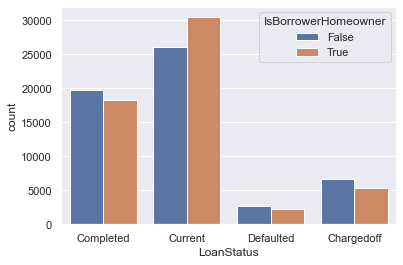

```python
sb.countplot(data = df_used_cols_loan_status, x = 'LoanStatus', hue = 'IsBorrowerHomeowner');
```

for qualitative columns, bar charts were used to depict the relationship between different qualitative variables. To start with the first chart, it highlights the relationship between `loan status and prosperRating`. firstly we can see current status outnumbered other categories. Secondly, we can see that in current category, C category has the highest loan compared to others. Regarding those who completed their loanS, we can see that D has the highest counts, which means people in that category are good in completing their loans. The second chart depict the loan status in accordance to homeowernship. Same as the first chart, current category outweighs others and we can see that people with home outnumbered people without home in current category.